[figure not shown]

[figure not shown]

[figure not shown]

# Introduction To Transcriptomics

Author

Affiliation

Dr Stevie Pederson (They/Them)  
stevie.pederson@thekids.org.au

Black Ochre Data Labs, The Kids Research Institute Australia

## Acknowledgement Of Country

I’d like to acknowledge the Kaurna people as the traditional owners and custodians of the land we know today as the Adelaide Plains, where I live & work.

I also acknowledge the deep feelings of attachment and relationship of the Kaurna people to their place.

I pay my respects to the cultural authority of Aboriginal and Torres Strait Islander peoples from other areas of Australia, and pay my respects to Elders past, present and emerging, and acknowledge any Aboriginal Australians who may be with us today

# What Is Transcriptomics

## What Is Transcriptomics?

> Transcription is the process of making an RNA copy of a gene sequence
- DNA can be described as being like a giant book of instructions
- Some regions are defined as *genes*
  - Originally considered to be the basic unit of inheritance
  - Now used to describe a region of DNA transcribed into RNA

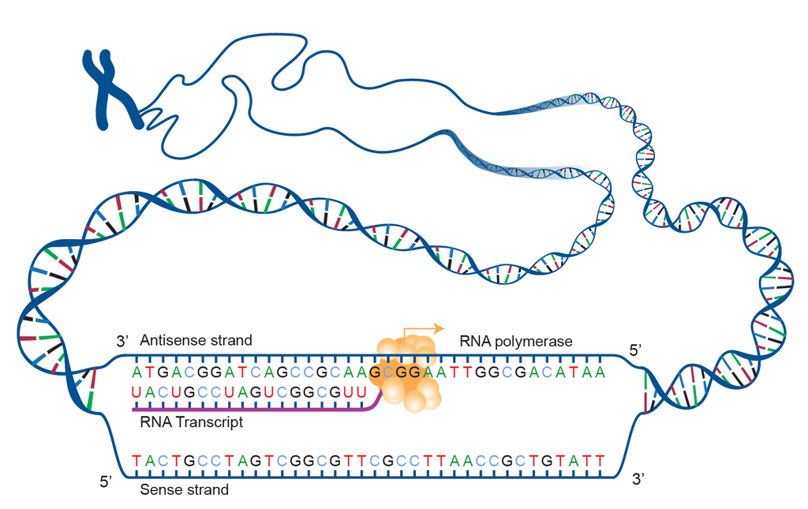

Figure taken from Anderson and Bartee (2016)

## What Is Transcriptomics?

> Transcriptomics is the study of transcribed RNA

Transcribed RNA falls into 2 broad classes

1. Messenger RNA (mRNA)
   - Codes for protein sequences
2. Non-coding RNA (ncRNA)
   - Multiple types of *functional* RNA
   - rRNA, tRNA $\implies$ protein translation
   - lncRNA, miRNA, snRNA, piRNA etc

Prokaryotes $\implies$ mRNA, rRNA & tRNA

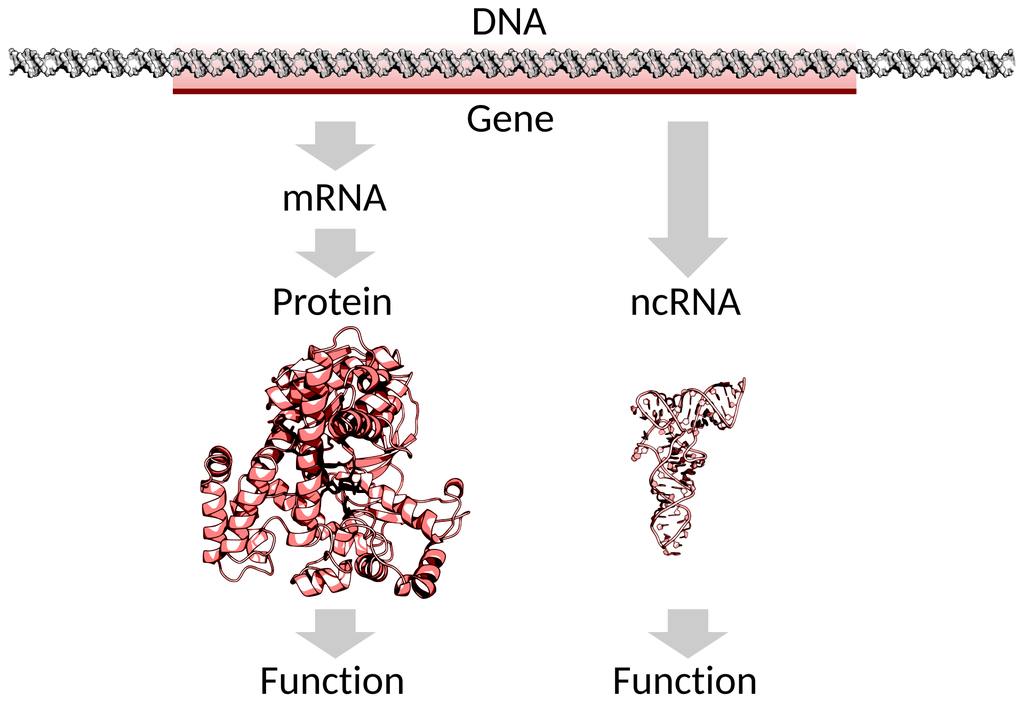

By Thomas Shafee - Own work, [CC BY 4.0](https://creativecommons.org/licenses/by/4.0), [Wikimedia Link](https://commons.wikimedia.org/w/index.php?curid=39441809)

## Functional RNA

[figure not shown]

https://xkcd.com/3056/

(An incomplete list)

- pre-mRNA + mRNA
- lncRNA + lincRNA
- miRNA, siRNA, shRNA, piRNA
- rRNA + tRNA
- snRNA + snoRNA
- SRP RNA
- eRNA
- circRNA

## The RNA Population Of a Eukaryotic Cell

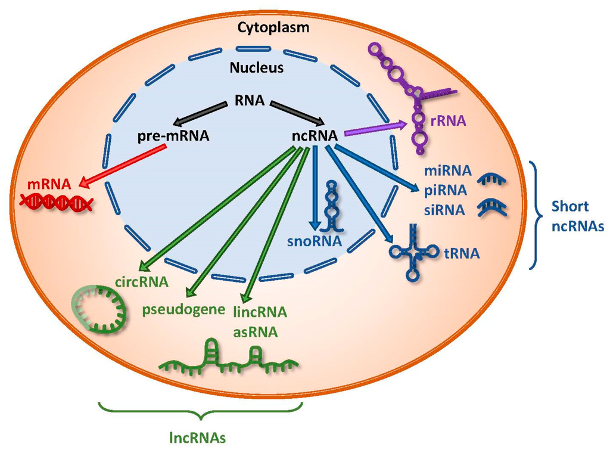

Image taken from Chan and Tay (2018)

- rRNA $\approx$ 80%<sup>1</sup>
- tRNA $\approx$ 15%
- All other RNA $\approx$ 5%

## Eukaryotic mRNA Processing

- Nuclear mRNA have 5’ cap added
  - Protects single-stranded mRNA from degradation
  - Regulates nuclear export
  - Promotes translation into protein
- mRNAs are polyadenylated at the 3’ end (-AAAAAAAAAAAAA)
  - Also protects from degradation
  - Aids in transcription termination, export and translation
- Introns are spliced out as required

## Eukaryotic mRNA Processing

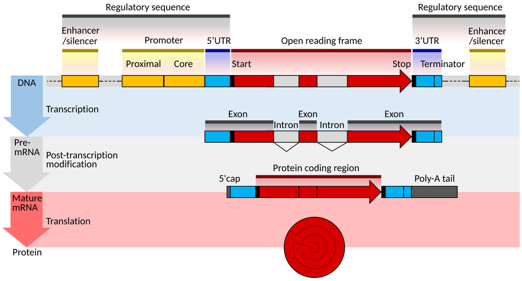

Taken from Shafee and Lowe (2017)

## Eukaryotic mRNA Processing

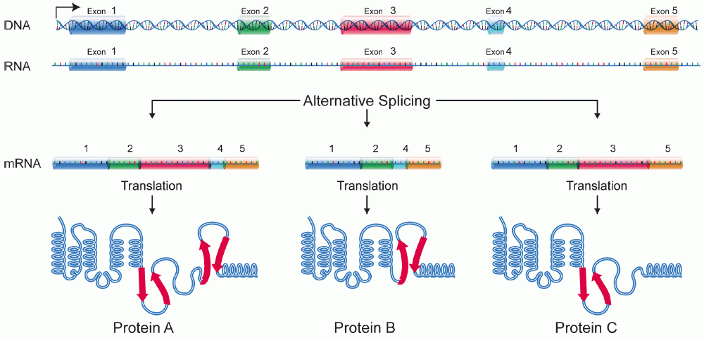

Image by the National Human Genome Research Institute

# Why Study Transcriptomics?

## Why Study Transcriptomics?

- Can infer specific cell-cell communication methods
- Identify therapeutic targets for Cardiovascular Disease, biomarkers for CAR-T cells etc
- Assumed to be low-level
  - DNA $\rightarrow$ RNA $\rightarrow$ Protein $\rightarrow$ Metabolites, Signalling molecules, etc …
- Is a snapshot of highly **dynamic biological processes**
  - Captures response to stimulus and steady-state dynamics
  - Also changes in steady-state over time
- RNA expression is a rapid, early response to stimuli
  - Could be immune signalling, drug treatment etc
- Use to make inference about these biological processes of interest

## Quantitative Approaches

- First trimester placenta is hypoxic $\implies$ later is normoxic
- How a disease associates with aging
- Change in a gene’s transcriptional activity $\implies$ change in RNA abundance
  - Capturing changes in abundance $\implies$ **measure RNA quantities**
- Changes in splicing patterns
  - Require methods for quantifying isoforms *within* a gene
  - May be changing proportions within gene-level abundances

## Sequence Based Approaches

- Identify novel transcript sequences
- No reference genome/transcriptome
  - Compare novel sequences against known transcriptomes $\implies$ infer function
- Unexpected splicing patterns and chimeric RNA
  - Real genomes are less “neat” than reference genomes
  - Can play a key role in leukaemias & other cancers $\implies$ clinical diagnostic

# The Development of Transcriptomics

## Early Transcriptomics

- The field developed with few reference sequences
  - Human Genome Project (1990-2003)
- Single sequence methods
  - Sequence Identification: Sanger Sequencing (1977)
  - Quantitative: Northern Blot (1977) + qPCR (1996)
- High-Throughput Era
  - Sequence Identification: ESTs (1991)
  - Quantitation: SAGE (1995) $\rightarrow$ Microarrays (1996)

## Northern Blots

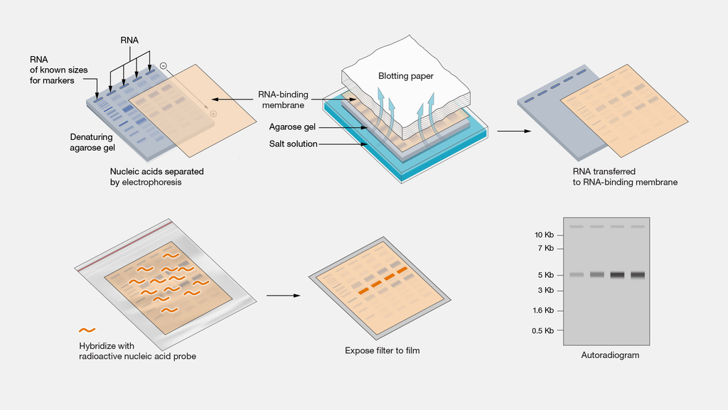

Figure taken from https://www.genome.gov/genetics-glossary/Northern-Blot

- Probes require sequence knowledge
- Clear Presence/Absence calls
- Crude quantitation: Densitometric Analysis

## RT-qPCR

The C<sub>T</sub> values is actually estimated to a decimal value

- “Gold-standard” for measurement of transcription levels
  - Single gene $\implies$ not a high-throughput technique
- Targets a single transcript region with specific primers to produce cDNA  
  $\rightarrow$ Polymerase Chain Reaction (PCR)
- Each PCR cycle approximately doubles the target region
- cDNA produced is identified using fluorophores
  - Fluorescence doubles with each cycle
- Once fluorescence passes a detection threshold, the cycle number is recorded
  - Known as the Cycle Threshold (C<sub>T</sub>) value

## RT-qPCR

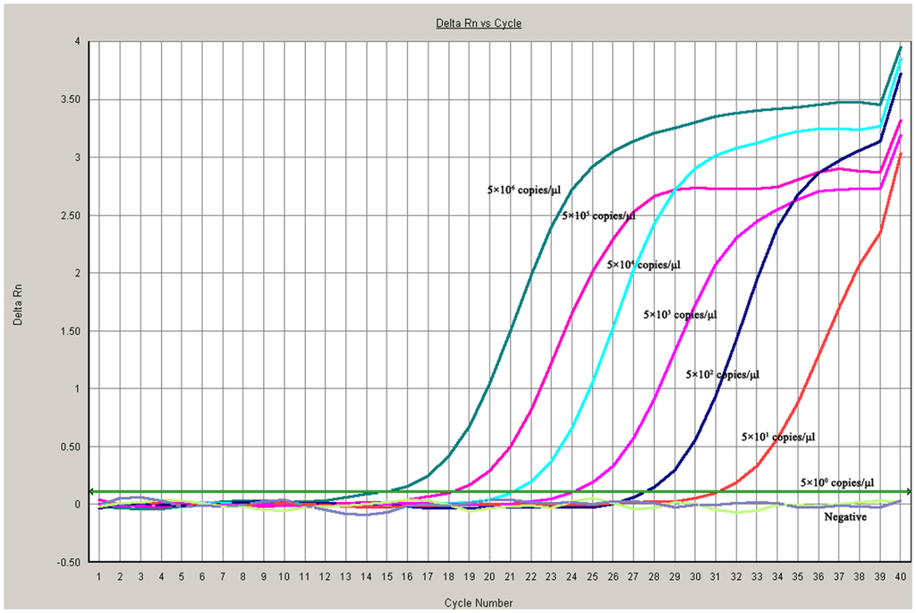

A 10-fold dilution series

## RT-qPCR

- We commonly compare abundances across experimental groups
  - e.g. Untreated/Control vs Treated
- In RT-PCR this is $\Delta\Delta C_T$ $\implies$ the change in $\Delta C_T$ values (Livak and Schmittgen 2001)
  - RNA compared after normalisation
- Different RNA abundances $\implies$ *Differential Gene Expression*
- We have used the $\log_2$ scale $\implies$ log Fold-Change (logFC)

## Serial Analysis of Gene Expression (SAGE)

- First high-throughput quantification method was *Serial Analysis of Gene Expression* (SAGE) (Velculescu et al. 1995)

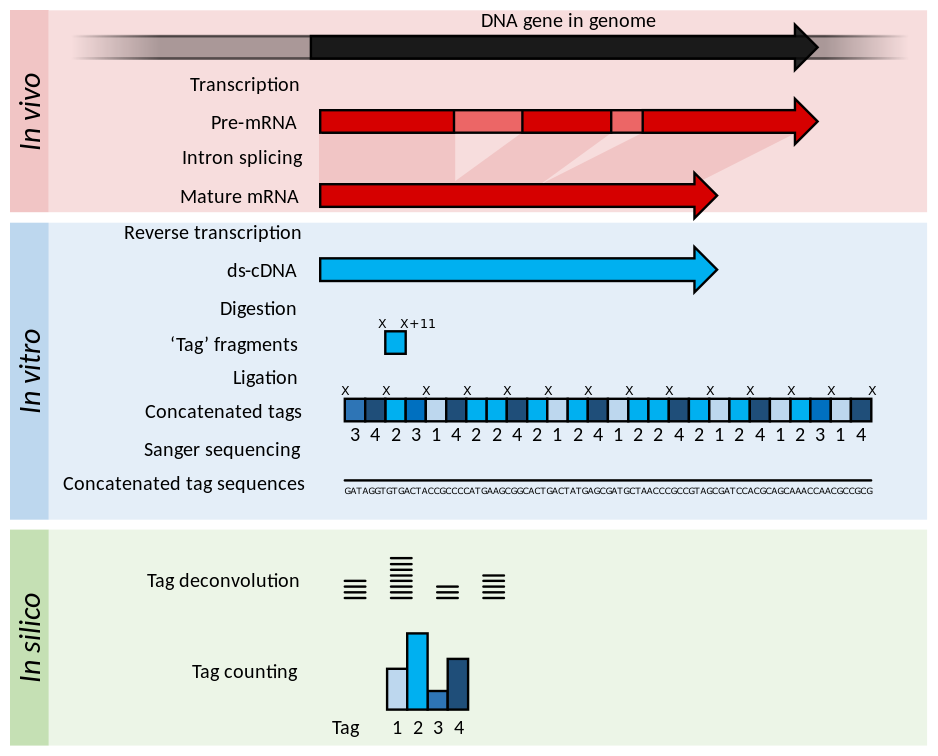

Thomas Shafee, [CC BY 4.0](https://creativecommons.org/licenses/by/4.0), via Wikimedia Commons

- mRNA $\rightarrow$ cDNA using biotinylated primers
- cDNA bound to beads (using biotin) & cleaved
- 11mer “tags” were ligated into long sequences using linker sequences
- Sequenced using Sanger Sequencing
- Deconvolution & counting
- First count-based transcriptomic methods developed

## Microarray Technology

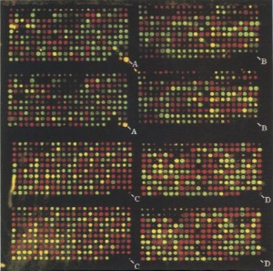

Section of two-colour array taken from Shalon, Smith, and Brown (1996)

- Truly launched the modern transcriptomics era
- Quantified thousands of transcripts simultaneously
- Relied on development of Human Genome Project  
  (+ other organisms)
- Analysis in R/Bioconductor
  - R v1.0.0 (2000)
  - Bioconductor (Gentleman et al. 2004)
  - Modern statistical high-throughput models developed

# References

Adams, Mark D., Jenny M. Kelley, Jeannine D. Gocayne, Mark Dubnick, Mihael H. Polymeropoulos, Hong Xiao, Carl R. Merril, et al. 1991. “Complementary DNA Sequencing: Expressed Sequence Tags and Human Genome Project.” *Science* 252 (5013): 1651–56. http://www.jstor.org/stable/2876333.

Anderson, Christine, and Lisa Bartee. 2016. *Mt Hood Community College Biology 102*. Open Oregon Educational Resources.

Chan, Jia Jia, and Yvonne Tay. 2018. “Noncoding RNA:RNA Regulatory Networks in Cancer.” *International Journal of Molecular Sciences* 19 (5). https://doi.org/10.3390/ijms19051310.

Gentleman, Robert C, Vincent J Carey, Douglas M Bates, Ben Bolstad, Marcel Dettling, Sandrine Dudoit, Byron Ellis, et al. 2004. “Bioconductor: Open Software Development for Computational Biology and Bioinformatics.” *Genome Biol.* 5 (10): R80.

Livak, Kenneth J., and Thomas D. Schmittgen. 2001. “Analysis of Relative Gene Expression Data Using Real-Time Quantitative PCR and the 2−ΔΔCT Method.” *Methods* 25 (4): 402–8. https://doi.org/https://doi.org/10.1006/meth.2001.1262.

Shafee, Thomas, and Rohan Lowe. 2017. “Eukaryotic and Prokaryotic Gene Structure.” *WikiJournal of Medicine*, January. https://doi.org/10.15347/WJM/2017.002.

Shalon, D, S J Smith, and P O Brown. 1996. “A DNA Microarray System for Analyzing Complex DNA Samples Using Two-Color Fluorescent Probe Hybridization.” *Genome Research* 6 (7): 639–45. https://doi.org/10.1101/gr.6.7.639.

Velculescu, V. E., L. Zhang, B. Vogelstein, and K. W. Kinzler. 1995. “Serial analysis of gene expression.” *Science* 270 (5235): 484–87.